# GTSeq

W. Babik, M. Dorohuntsev

2024-10-14

## Introduction

We start with vcf, in which all genotypes with fewer than 8 reads or with GQ < 20 were set to missing and then all SNPs with > 50% missing data were filtered out.

## Read vcf, extract info about markers and positions of individual SNPs

```r
#read vcf and convert into genind
v <- read.vcfR("data/final.vcf")
```

```
## Scanning file to determine attributes.
## File attributes:
##   meta lines: 489
##   header_line: 490
##   variant count: 896
##   column count: 296
## Meta line 489 read in.
## All meta lines processed.
## gt matrix initialized.
## Character matrix gt created.
##   Character matrix gt rows: 896
##   Character matrix gt cols: 296
##   skip: 0
##   nrows: 896
##   row_num: 0
## Processed variant: 896
## All variants processed
```

```r
g <- vcfR2genind(v, return.alleles = TRUE)
#dataframe with marker/SNP info
SNPinf <- data.frame(genind_loc = locNames(g)) %>%
  mutate(marker = str_remove(genind_loc, "_[0-9]+_[0-9]+$"),
         pos = as.numeric(str_extract(genind_loc, "_([0-9]+)_[0-9]+$", group = 1)))
```

## Select SNPs and alleles of interest

Calculate allele frequencies, number of alleles, and global MAF for each SNP

```r
#vector of allele frequencies converted into df
af <- apply(tab(g, freq=TRUE), 2, mean, na.rm=TRUE)
af_df <- data.frame(allele = names(af), freq = af) %>%
  mutate(marker = str_remove(allele, "_[0-9]+_[0-9]+[.].+$"),
         pos = as.numeric(str_extract(allele, "_([0-9]+)_[0-9]+[.].+$", group = 1)))
row.names(af_df) <- NULL

#number of alleles and MAF for each marker
af_info <- af_df  %>%
  group_by(marker, pos) %>% summarise(Nall = n(),
                                      MAF = 1 - max(freq))
row.names(af_info) <- NULL
```

Identify SNP with the highest MAF for each marker, select only markers with MAF >=0.1, identify the most common allele for each SNP, plot fraction of missing data.

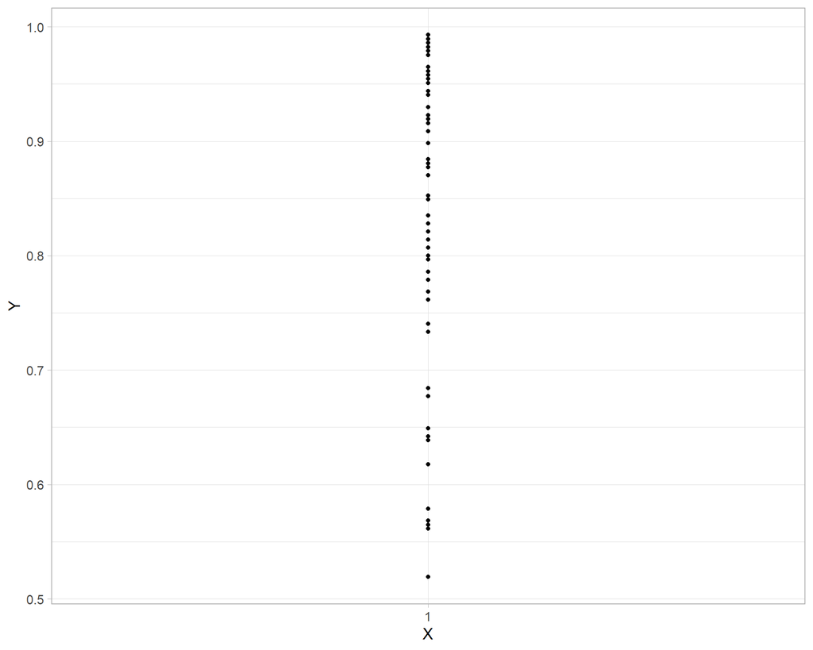

```r
#SNP with the highest MAF for each marker
af_sum <- af_info %>% group_by(marker) %>% slice_max(order_by = MAF, n = 1, with_ties = FALSE)

#markers with three-allelic SNPs, these can be handled by pooling the two rarer alleles, but as there are only a few of them, I decided to drop them for the moment
three_all <- af_sum %>% filter(Nall == 3)

#set of loci to analyse, including threeallelic
lset <- af_sum %>% filter(MAF >= 0.1) %>% left_join(SNPinf, by = c("marker", "pos")) %>%
  pull(genind_loc)

#subset genind obj to get only SNPs of interest
gind <- g[loc = lset]

#alleles of interest

alleles <- af_df %>% mutate(SNP = str_remove(allele, "[.][ACTGN-]+$")) %>%
  filter(SNP %in% lset) %>% group_by(SNP) %>% slice_max(order_by = freq, with_ties = FALSE) %>% pull(allele)

#fraction of typed individuals, vector that we plot
fr_typed <- data.frame(X = as.factor(1), Y = propTyped(gind, by = "loc"))
ggplot(fr_typed, aes(x = X, y = Y)) + geom_point() +
  theme_light(base_size = 14)
```

## Population based analyses

### Adding metainfo and calculating sample sizes

Get populations for individuals and add this info to genind. Note, that populations are based on the information in bam names. Additionally, the translation table contains information about the three populations for which pgdh allele frequencies in both autumn and spring were available (`locality` and `seasona - for the remaining populations set to`NA`).

```r
#translation table of population names
poptr <- read_tsv("data/pop_translation_table.txt")


#get individual names as data frame
s <- data.frame(ID = indNames(gind)) %>%
  mutate(temp = str_extract(ID, "sorted.(.+)_001.bam", group = 1),
         sample = str_extract(temp, "-([0-9]+)$", group = 1),
         pop_orig = str_remove(temp, "-([0-9]+)$")) %>%
  left_join(poptr, by = "pop_orig") %>%
  mutate(sample = paste(pop, sample, sep = "-"))
#set population and indnames using df from above
pop(gind) <- s$pop
indNames(gind) <- s$sample
```

sample sizes for populations

```r
pop_ss <- s %>% group_by(pop) %>% summarise(N = n())
kable(pop_ss)
```

| pop | N |
| --- | --- |
| 1-a-j | 35 |
| 10-a-j | 10 |
| 10-b-j | 12 |
| 13-w | 19 |
| 15-j | 20 |
| 2-a-w | 24 |
| 2-b-j | 4 |
| 4-a-w | 1 |
| 4-b-w | 19 |
| 5-1-j | 36 |
| 5-1-w | 33 |
| 9-1-w | 6 |
| 9-2-j | 29 |
| 9-2-w | 18 |
| 9-4-j | 19 |

sample sizes for pooled populations

```r
poolpop_ss <- s %>% group_by(pool_pop) %>% summarise(N = n())
kable(poolpop_ss)
```

| pool_pop | N |
| --- | --- |
| 1-j | 35 |
| 10-j | 22 |
| 13-w | 19 |
| 15-j | 20 |
| 2-j | 4 |
| 2-w | 24 |
| 4-w | 20 |
| 5-j | 36 |
| 5-w | 33 |
| 9-j | 48 |
| 9-w | 24 |

### Hardy-Weinberg

Hardy-Weinberg tests for populations with sample sizes > 15

```r
min15 <- pop_ss %>% filter(N > 15) %>% pull(pop)
HWE <- lapply(min15, function(x){
  p <- gind[pop(gind) == x, ]
  hw <- hw.test(p, B = 1000)
  hwdf <- data.frame(pop = x, SNP = row.names(hw), Pchi2 = hw[, 3], Pex = hw[, 4])
  row.names(hwdf) <- NULL
  return(hwdf)}) %>% bind_rows()
```

and summary of significant results by SNP and population

```r
HWE_SNP_sum <- HWE %>% group_by(SNP) %>% summarise(p_0_05 = sum(Pex < 0.05),
                                                   p_0_01 = sum(Pex < 0.01)) %>%
  arrange(desc(p_0_05))

kable(HWE_SNP_sum)
```

| SNP | p_0_05 | p_0_01 |
| --- | --- | --- |
| my_sq0051_1073553::sq0051:1073452-1073653_88_577 | 7 | 5 |
| my_sq0015_597464::sq0015:597363-597564_90_374 | 6 | 4 |
| chosen2_sq0002_1280511::sq0002:1280410-1280611_170_113 | 5 | 2 |
| chosen2_sq0009_769410::sq0009:769309-769510_88_272 | 5 | 3 |
| chosen2_sq0004_5501616::sq0004:5501515-5501716_157_201 | 4 | 3 |
| chosen3_sq0037_531877::sq0037:531776-531977_120_559 | 4 | 4 |
| 200k_07_22_sq0011_3279328::sq0011:3279227-3279428_143_717 | 3 | 0 |
| 200k_07_22_sq0039_192038::sq0039:191937-192138_94_789 | 3 | 1 |
| chosen2_sq0006_1501966::sq0006:1501865-1502066_101_243 | 3 | 3 |
| chosen2_sq0006_703026::sq0006:702925-703126_99_240 | 3 | 2 |
| chosen2_sq0028_299821::sq0028:299720-299921_132_494 | 3 | 2 |
| chosen2_sq0003_1924495::sq0003:1924394-1924595_71_139 | 2 | 1 |
| chosen3_sq0002_3848978::sq0002:3848877-3849078_78_120 | 2 | 0 |
| my_sq0004_4831528::sq0004:4831427-4831628_172_189 | 2 | 0 |
| 200k_07_22_sq0003_7601487::sq0003:7601386-7601587_125_639 | 1 | 1 |
| 200k_07_22_sq0004_4743202::sq0004:4743101-4743302_76_645 | 1 | 1 |
| 200k_07_22_sq0007_3662298::sq0007:3662197-3662398_115_676 | 1 | 1 |
| 200k_07_22_sq0010_2025424::sq0010:2025323-2025524_92_683 | 1 | 0 |
| chosen2_sq0011_811466::sq0011:811365-811566_137_302 | 1 | 1 |
| chosen2_sq0022_1208044::sq0022:1207943-1208144_143_471 | 1 | 0 |
| chosen3_sq0002_4929626::sq0002:4929525-4929726_152_133 | 1 | 0 |
| chosen3_sq0035_935012::sq0035:934911-935112_92_535 | 1 | 0 |
| chosen3_sq0066_622207::sq0066:622106-622307_152_602 | 1 | 0 |
| my_sq0003_6544179::sq0003:6544078-6544279_62_160 | 1 | 1 |
| my_sq0010_2843588::sq0010:2843487-2843688_55_287 | 1 | 1 |
| pgdh15-20kb+_sq0001_5247304::sq0001:5247203-5247404_108_50 | 1 | 1 |
| 200k_07_22_sq0002_1685450::sq0002:1685349-1685550_97_612 | 0 | 0 |
| 200k_07_22_sq0003_1923184::sq0003:1923083-1923284_154_626 | 0 | 0 |
| 200k_07_22_sq0003_4990996::sq0003:4990895-4991096_149_634 | 0 | 0 |
| 200k_07_22_sq0005_788113::sq0005:788012-788213_94_657 | 0 | 0 |
| 200k_07_22_sq0007_2053868::sq0007:2053767-2053968_149_666 | 0 | 0 |
| 200k_07_22_sq0007_2839079::sq0007:2838978-2839179_101_669 | 0 | 0 |
| 200k_07_22_sq0019_323521::sq0019:323420-323621_137_724 | 0 | 0 |
| 200k_07_22_sq0023_878491::sq0023:878390-878591_109_760 | 0 | 0 |
| 200k_07_22_sq0026_1515284::sq0026:1515183-1515384_120_767 | 0 | 0 |
| 200k_07_22_sq0030_887996::sq0030:887895-888096_106_774 | 0 | 0 |
| 200k_07_22_sq0053_343331::sq0053:343230-343431_65_807 | 0 | 0 |
| 200k_07_22_sq0060_260073::sq0060:259972-260173_101_830 | 0 | 0 |
| 200k_07_22_sq0064_148128::sq0064:148027-148228_168_849 | 0 | 0 |
| 200k_07_22_sq0068_775642::sq0068:775541-775742_125_856 | 0 | 0 |
| 200k_07_22_sq0074_286273::sq0074:286172-286373_110_865 | 0 | 0 |
| 200k_07_22_sq0075_205966::sq0075:205865-206066_46_877 | 0 | 0 |
| chosen2_sq0001_7751286::sq0001:7751185-7751386_128_80 | 0 | 0 |
| chosen2_sq0005_821254::sq0005:821153-821354_105_202 | 0 | 0 |
| chosen2_sq0011_1335895::sq0011:1335794-1335995_116_316 | 0 | 0 |
| chosen2_sq0032_787789::sq0032:787688-787889_56_508 | 0 | 0 |
| chosen3_sq0001_8428955::sq0001:8428854-8429055_62_89 | 0 | 0 |
| chosen3_sq0004_1024491::sq0004:1024390-1024591_101_166 | 0 | 0 |
| chosen3_sq0005_5743721::sq0005:5743620-5743821_174_229 | 0 | 0 |
| chosen3_sq0017_455207::sq0017:455106-455307_140_395 | 0 | 0 |
| chosen3_sq0042_1393411::sq0042:1393310-1393511_92_564 | 0 | 0 |
| my_sq0001_6466653::sq0001:6466552-6466753_114_69 | 0 | 0 |
| my_sq0005_1807549::sq0005:1807448-1807649_117_218 | 0 | 0 |
| my_sq0006_3718466::sq0006:3718365-3718566_83_247 | 0 | 0 |
| my_sq0007_1683348::sq0007:1683247-1683448_116_261 | 0 | 0 |
| my_sq0022_345635::sq0022:345534-345735_140_420 | 0 | 0 |
| my_sq0028_1207230::sq0028:1207129-1207330_55_499 | 0 | 0 |
| my_sq0033_1581453::sq0033:1581352-1581553_65_516 | 0 | 0 |
| my_sq0061_1136193::sq0061:1136092-1136293_45_594 | 0 | 0 |
| pgdh15-20kb-_sq0001_5208913::sq0001:5208812-5209013_145_27 | 0 | 0 |
| pgdh5-10kb+_sq0001_5238245::sq0001:5238144-5238345_151_42 | 0 | 0 |

```r
HWE_pop_sum <- HWE %>% group_by(pop) %>% summarise(p_0_05 = sum(Pex < 0.05),
                                                   p_0_01 = sum(Pex < 0.01)) %>%
  arrange(desc(p_0_05))
```

so deviations from HW frequencies are not extensive and we keep all markers.

### PCA

Overall genetic differentiation - PCA

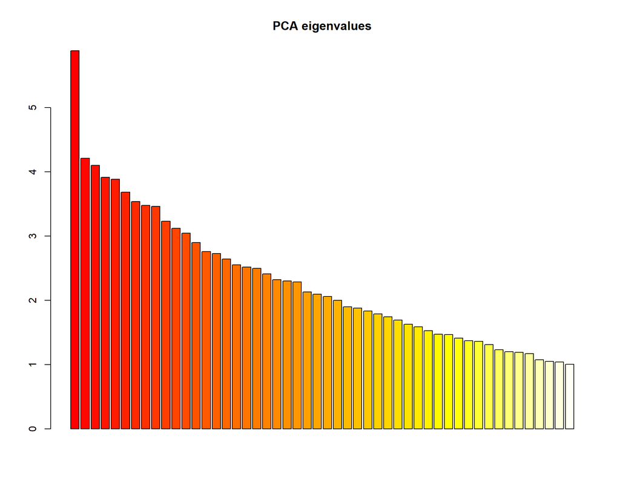

```r
X <- scaleGen(gind, NA.method="mean")
pca <- dudi.pca(X,cent=FALSE,scale=FALSE,scannf=FALSE,nf=3)
barplot(pca$eig[1:50],main="PCA eigenvalues", col=heat.colors(50))
```

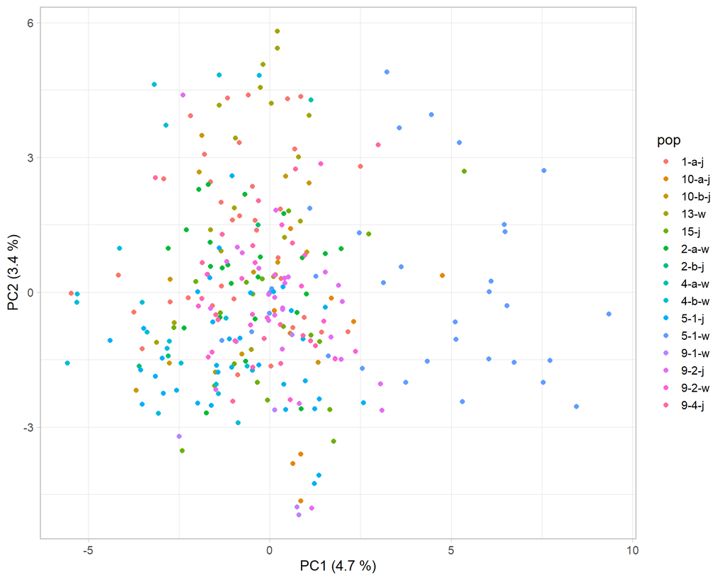

```r
#percentage of variation explained by first three PC2
perc_expl <- 100 * c(pca$eig[1], pca$eig[2], pca$eig[3]) / sum(pca$eig)
PCAdf <- as_tibble(pca$li, rownames = "sample") %>% left_join(s, by = "sample")
ggplot(PCAdf, aes(x = Axis1, y = Axis2, colour = pop)) +
  geom_point(size = 2) +
  labs(x = paste0("PC1 (", round(perc_expl[1], 1) , " %)"),
       y = paste0("PC2 (", round(perc_expl[2], 1) , " %)")) +
  theme_light(base_size = 14)
```

and PCA with pooled populations

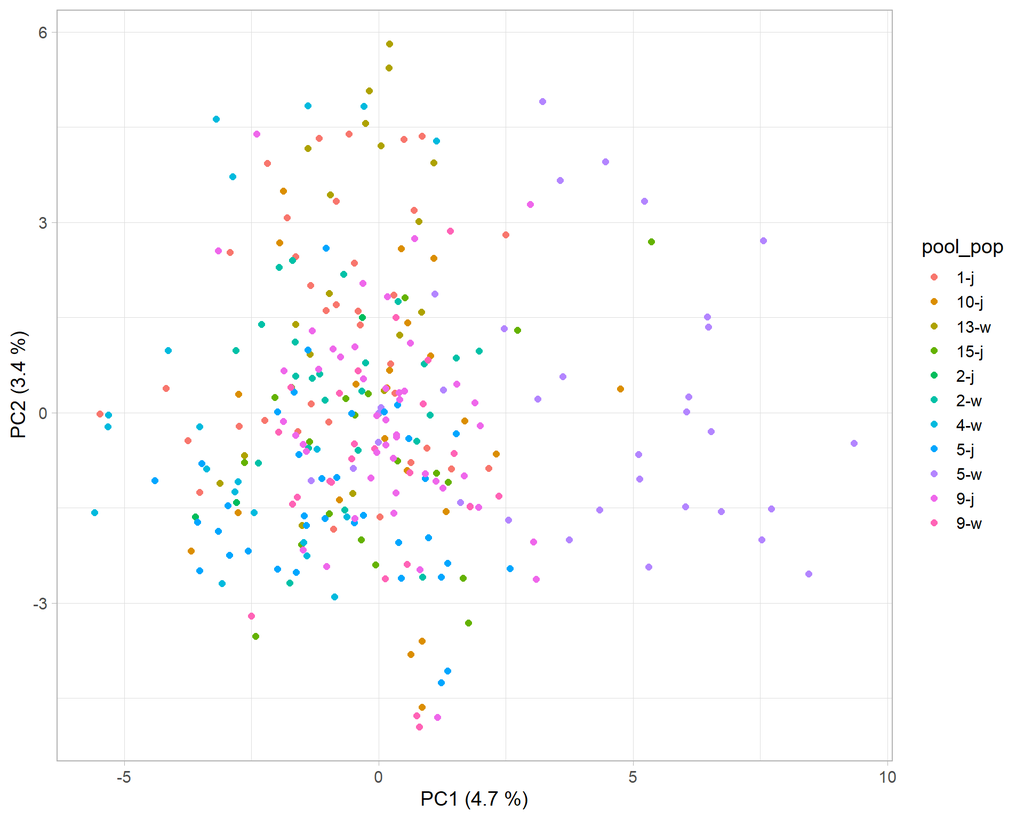

```r
ggplot(PCAdf, aes(x = Axis1, y = Axis2, colour = pool_pop)) +
  geom_point(size = 2) +
  labs(x = paste0("PC1 (", round(perc_expl[1], 1) , " %)"),
       y = paste0("PC2 (", round(perc_expl[2], 1) , " %)")) +
  theme_light(base_size = 14)
```

and only pops with both seasons and good sample size visualised

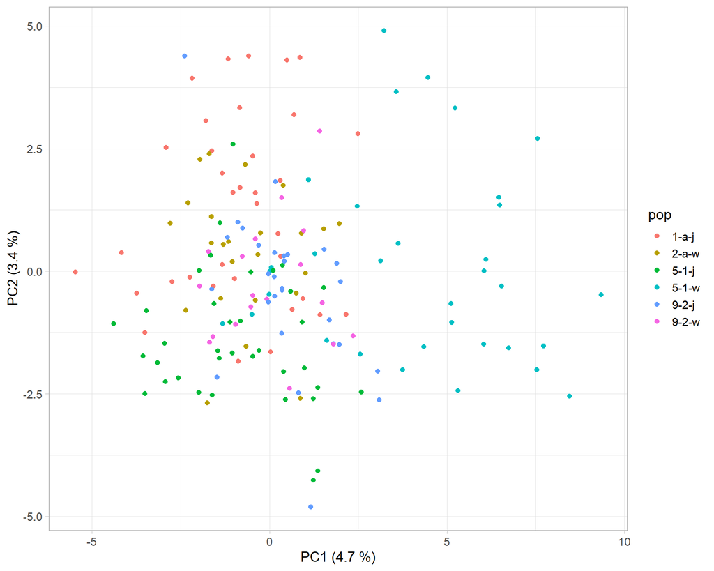

```r
PCAdf_seas <- PCAdf %>% filter(!is.na(locality))
ggplot(PCAdf_seas, aes(x = Axis1, y = Axis2, colour = pop)) +
  geom_point(size = 2) +
  labs(x = paste0("PC1 (", round(perc_expl[1], 1) , " %)"),
       y = paste0("PC2 (", round(perc_expl[2], 1) , " %)")) +
  theme_light(base_size = 14)
```

Allele frequency differences between season, we have only three pairs of populations.

```r
sp <- PCAdf_seas %>% pull(pop) %>% unique()

#genind with pops of interest only
gind_seas <- gind[pop(gind) %in% sp,]

ids_seas <- data.frame(sample = indNames(gind_seas)) %>% left_join(PCAdf_seas, by = "sample") %>%
  mutate(loc_seas = paste(locality, season, sep = "_"))

pop(gind_seas) <- ids_seas$loc_seas

pop_af <- lapply(ids_seas$loc_seas %>% unique(), function(x){
  p <- gind_seas[pop(gind_seas) == x, ]
  pf <- apply(tab(p, freq = TRUE), 2, mean, na.rm = TRUE)
  pdf <- data.frame(pop = x, allele = names(pf), freq = pf)
  row.names(pdf) <- NULL
  return(pdf)
  }) %>% bind_rows()

seas_pop_alleles <- pop_af %>% filter(allele %in% alleles) %>% mutate(MAF = 1-freq) %>%
  mutate(pop_id = pop,
         pop = str_remove(pop_id, "_.+"),
         season = str_extract(pop_id, "_(.+)", group = 1)) %>%
  select(pop, season, allele, MAF) %>%
  pivot_wider(names_from = season, values_from = MAF) %>%
  mutate(delta = abs(autumn - spring),
         meanMAF = (autumn + spring) / 2)

#fake pgdh data
pgdh <- read_tsv("data/pgdh_allele_frequencies.txt") %>%
    mutate(delta = abs(autumn - spring),
         meanMAF = (autumn + spring) / 2) %>% rename(pop = locality)
```

Plot relationship between delta and average MAF, colour by pop, mark pgdh.

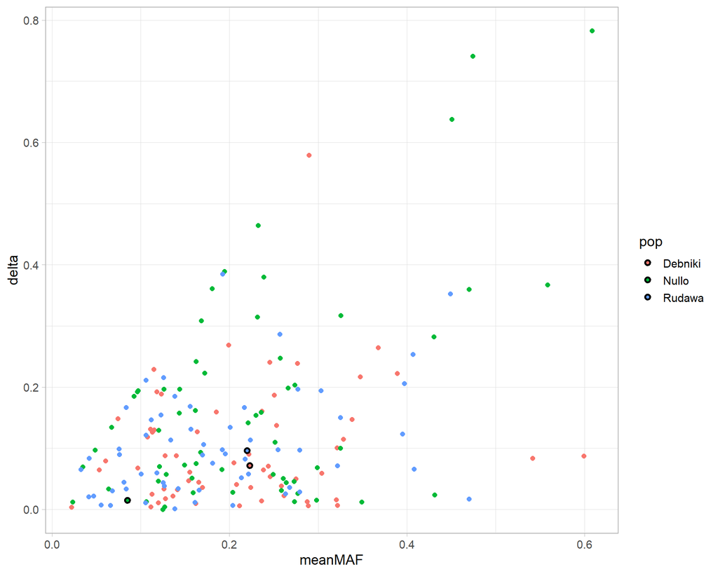

```r
ggplot(seas_pop_alleles, aes(x = meanMAF, y = delta, colour = pop)) +
  geom_point(size = 2) +
  geom_point(data = pgdh, aes(fill = pop), pch = 21, colour = "black", stroke = 1.5) +
  theme_light(base_size = 14)
```

## Conclusions

- there’s very little genetic differentiation between localities
- for sure, pgdh allele frequency changes between season are not larger than for other markers; I don’t think we need a more sophisticated analysis at this point